# GGPLOT2 Tutorial

## Line graphs using the Gapminder Dataset

Let’s look at life expectancy a bit more in depth. We will be using both `dplyr` and `ggplot` together in this example. Let’s plot the life expectancy rate in the United States.

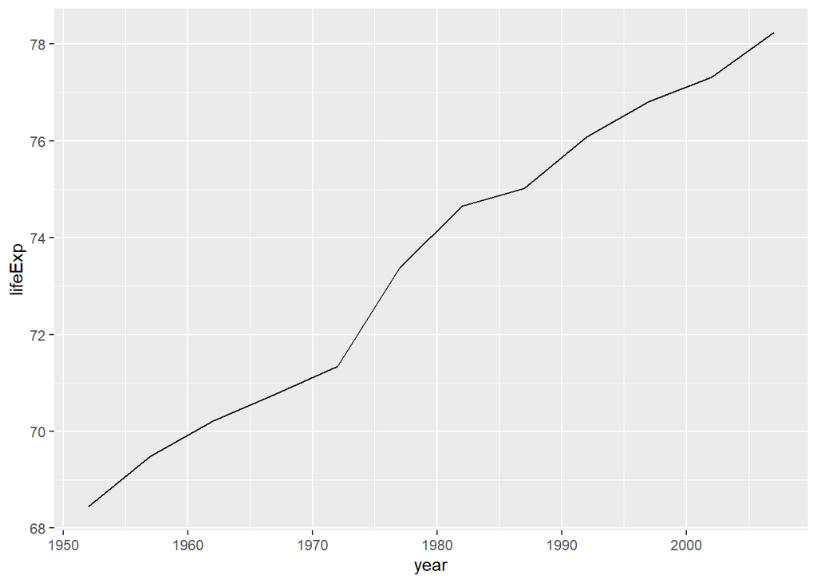

```r
gapminder %>%
  filter(country == "United States") %>%
  ggplot(aes(x=year, y=lifeExp)) +
  geom_line()
```

How about if we want to compare a few countries. Note in “geom_line” I asked to make the line a bit thicker using the “size” command.

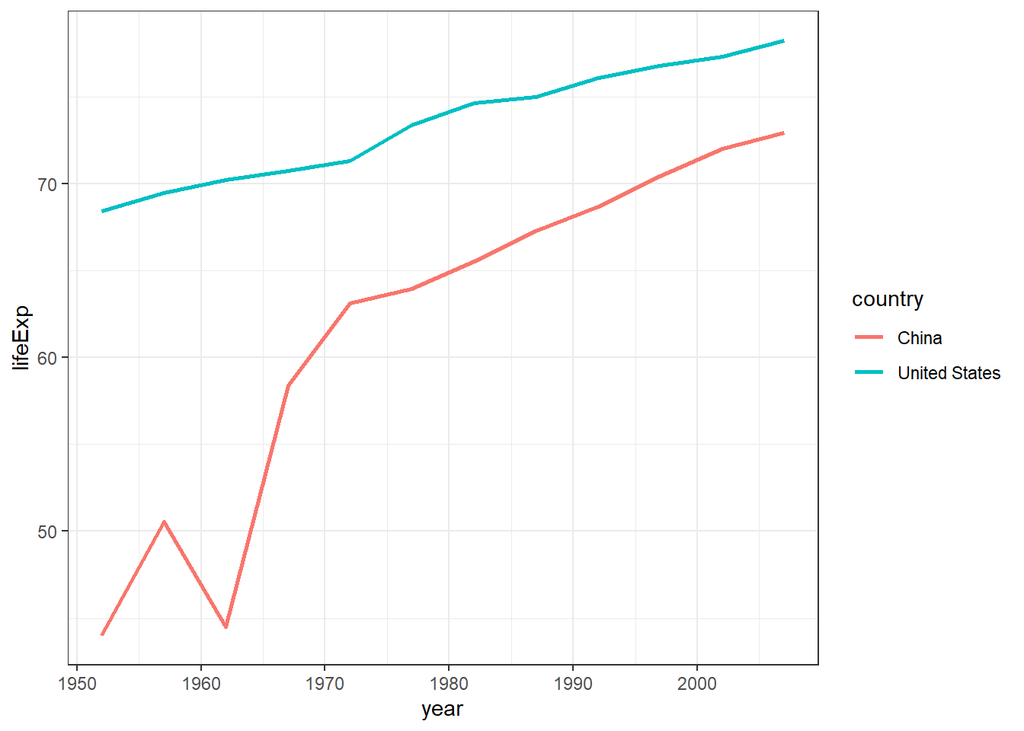

```r
countries <- c("United States", "China")

gapminder %>% filter(country %in% countries) %>%
  ggplot(aes(x=year,y=lifeExp, color = country)) +
  geom_line(size = 1)+
  theme_bw()
```

## Let’s Make Choropleth Map

Let’s make sure we have all the necessary packages.

```r
library(tidyverse)
library(maps)
library(ggmap)
library(countrycode)
library(RColorBrewer)
library (ggthemes)
library (sf)
library (ggsci)
library (extrafont)
library (viridis)
```

We will use the data collected by Jeehae and Julia on ICERD’s ratification status.

We will wrangle and prepare the data.

```r
# Read the data from the GitHub repository:

hr <- read.csv ("https://raw.githubusercontent.com/world-politics-datalab/humanrights-treaties-ratification-status/main/hr_status_icerd.csv")

#For mapping purposes, we will add Greenland to the dataset. Greenland is a Danish territory. So we will add the same information as Denmark's. This is the "dplyr" code

hr_gr <- hr %>%
  add_row(iso2 = "GL", member= "Greenland", state.party = 1, year.ratification.or.accession= 1971, signatory=0, no.action=0,status="state party")

# Let's merge the information on Greenland back to "hr" dataset:

hr <- hr_gr

# The ISO2 abbreviation for Namibia is NA, but R read the NA as n/a. We need to fix this. So I used the "countrycode" package to enter all the ISO2 abbreviations, fixing the problem.

hr$iso2 <- countrycode (hr$member, origin= "country.name", destination = "iso2c", )
```

We need to get a dataset with a world map, including longitude and latitude data. We need to use `ggplot` to see what we are working with.

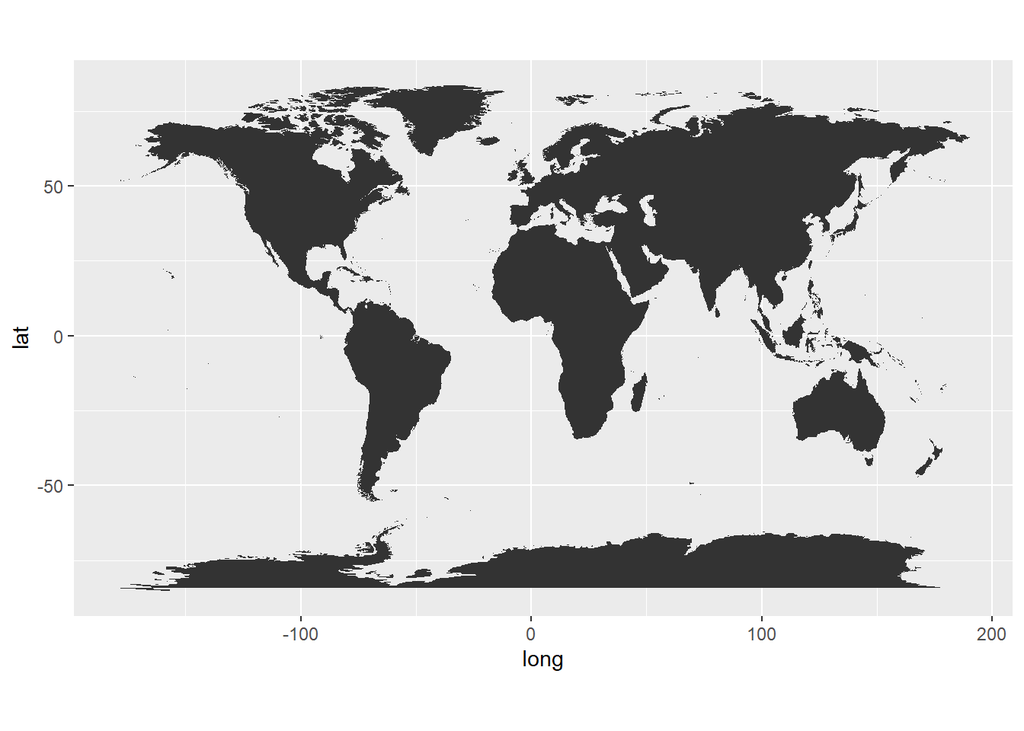

```r
wmap <- map_data ("world")

# check the map using ggplot:

worldplot <- ggplot()+
  geom_polygon(data=wmap, aes(x=long, y=lat, group = group))+
  coord_fixed(1.3)

worldplot
```

We will use `dplyr` to combine the two datasets.

```r
#let's add iso2

wmap$iso2 <- countrycode (wmap$region, origin= "country.name", destination = "iso2c", )
```

```r
#join the map with the hr data

wmap_hr <- wmap %>%
  left_join (hr, by = c("iso2" = "iso2"))

## filter out NAs

wmap_hr <- filter(wmap_hr, !is.na(status))
```

Now we can use `ggplot` to create the map.

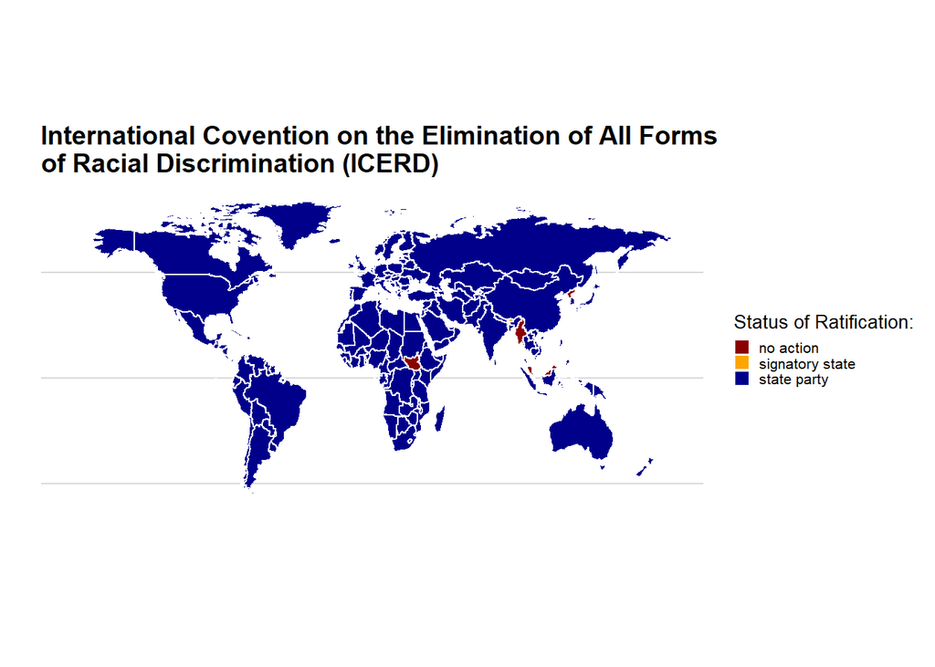

```r
ggplot(wmap_hr, aes(long, lat, group = group)) +
  coord_fixed(1.3)+
  geom_polygon(aes(fill = status))+
  geom_polygon(data =wmap_hr, colour = "white", fill = NA) +
  ggtitle("International Covention on the Elimination of All Forms\nof Racial Discrimination (ICERD)") +
  scale_y_continuous()+
  scale_fill_manual (values = c("darkred", "orange", "darkblue"))+
  #scale_fill_aaas ()+
  theme_hc()+
  theme(axis.text.x = element_blank(),
        axis.text.y = element_blank(),
        axis.ticks = element_blank(),
        rect = element_blank())+
  theme(plot.title = element_text(size = 14))+
    theme(plot.title = element_text(face = "bold"))+
    theme (legend.position = "right",
         legend.title = element_text(color = "black", size=10),
         legend.text = element_text (color = "black", size =8),
         legend.key.size = unit(0.3, 'cm'),
        legend.key.height = unit(0.3, 'cm'),
        legend.key.width = unit(0.3, 'cm'),
         )+
  labs (fill = "Status of Ratification:",
        x="",
        y= "")
```

#FINITO!!!

Feel free to email: cyordan@drew.edu with questions.